# primo_progetto

Author

Gloria Gasparini

Published

March 20, 2026

# Primo capitolo

Questo documento va ad analizzare il file di Sara.dataset

```r
rm(list=ls())
```

```r
library(readxl)
Sara_dataset <- read_excel("C:/Users/gaspa/OneDrive/Desktop/ARCA/Gloria_presentations/Sara_dataset.xls")
View(Sara_dataset)
```

- Faccio la media della variabile mathquiz

```r
mean(Sara_dataset$mathquiz, na.rm = TRUE)
```

```
[1] 29.07059
```

- colonna 1 colonna riferita alla variabile phobia = autovalutazione del timore verso la matematica su scala 0-10

```r
Sara_dataset$phobia
```

```
  [1]  1  1  4  4 10  4  4  4  4  5  3  5  4  4  8  4  7  0  5  4  3  4  4  0  1
 [26]  3  4  1  0  5  2  1  4  9  2  8  0  3  4  3  4  2  1  0  5  3  4  4 10  2
 [51]  5  7  1  2  3  4  2  0  1  7  1  5  5  1  3  3  5  3  1  5  0  0  2  6  2
 [76]  3  2  5 10  4  3  3  8  3  3  2  1  1  1  8  3  0  4  0  2  0  0  2  7  1
```

- colonna con la variabile mathquiz = punteggio ad un pre-test di matematica

```r
Sara_dataset$mathquiz
```

```
  [1] 43 49 26 29 31 20 13 23 38 NA 21 29 32 NA NA 37 18 32 37 21 NA NA 25 47 41
 [26] 22 35 26 39 22 10 20 26 21 30 35 40 NA 44 35 26 42 39 NA NA 15 24 NA 26 33
 [51] 38 14 29 NA 45 28 31 33 32 15 34 26 26 32 21 43 NA 37 NA 30 30 30 28 46 34
 [76] NA 32 33 14 29  9 11 30 15 32 25 22 31 NA 18 11 11 28 37 39 33 28 38 NA 41
```

- analizzo la relazione tra phobia autopercepita e punteggio ad un pre-test di matematica `
1. Scatter plot

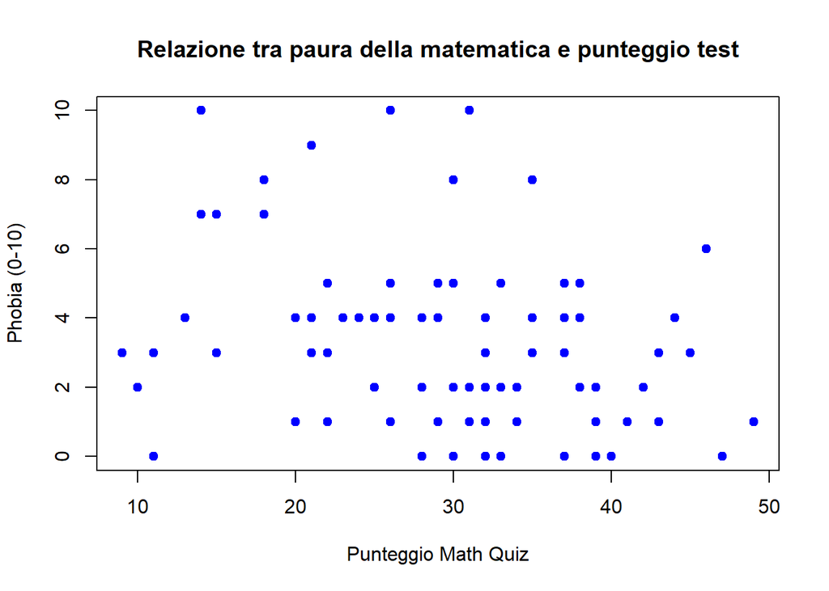

```r
# 1. Scatter plot
plot(Sara_dataset$mathquiz, Sara_dataset$phobia,
     main = "Relazione tra paura della matematica e punteggio test",
     ylab = "Phobia (0-10)",
     xlab = "Punteggio Math Quiz",
     pch = 19, col = "blue")
```

```r
# 2. Correlazione (Pearson)
correlazione <- cor(Sara_dataset$phobia, Sara_dataset$mathquiz, method = "pearson", use = "complete.obs")
print(correlazione)
```

```
[1] -0.2823864
```

```r
# Test di significatività della correlazione
cor.test(Sara_dataset$phobia, Sara_dataset$mathquiz)
```

```
    Pearson's product-moment correlation

data:  Sara_dataset$phobia and Sara_dataset$mathquiz
t = -2.6818, df = 83, p-value = 0.008833
alternative hypothesis: true correlation is not equal to 0
95 percent confidence interval:
 -0.46738185 -0.07369765
sample estimates:
       cor
-0.2823864
```

```r
# 3. Regressione lineare
modello <- lm(mathquiz ~ phobia, data = Sara_dataset)
summary(modello)
```

```
Call:
lm(formula = mathquiz ~ phobia, data = Sara_dataset)

Residuals:
     Min       1Q   Median       3Q      Max
-21.5583  -5.4101   0.4417   6.7382  19.8864

Coefficients:
            Estimate Std. Error t value Pr(>|t|)
(Intercept)  32.5583     1.6359  19.903  < 2e-16 ***
phobia       -1.0741     0.4005  -2.682  0.00883 **
---
Signif. codes:  0 '***' 0.001 '**' 0.01 '*' 0.05 '.' 0.1 ' ' 1

Residual standard error: 9.149 on 83 degrees of freedom
  (15 osservazioni eliminate a causa di valori mancanti)
Multiple R-squared:  0.07974,   Adjusted R-squared:  0.06865
F-statistic: 7.192 on 1 and 83 DF,  p-value: 0.008833
```

- Interpretazione: Intercetta= 32.5583, ovvero Se una persona non ha fobia, il punteggio medio previsto è circa 32.6 Coefficiente di phobia = -1.0741, ovvero effetto negativo → più fobia = peggior performance Significatività statistica: phobia = 0.00883 > significativo → la fobia ha davvero effetto sul punteggio Multiple R-squared (regressione lineare): 0.07974 > La fobia spiega solo l’8% della variabilità del punteggio

Quindi: effetto significativo, ma debole in termini di spiegazione

# Secondo capitolo

- Quante persone frequentano ogni corso

```r
table(Sara_dataset$major)
```

```
 1  2  3  4  5
29 25 21 15 10
```

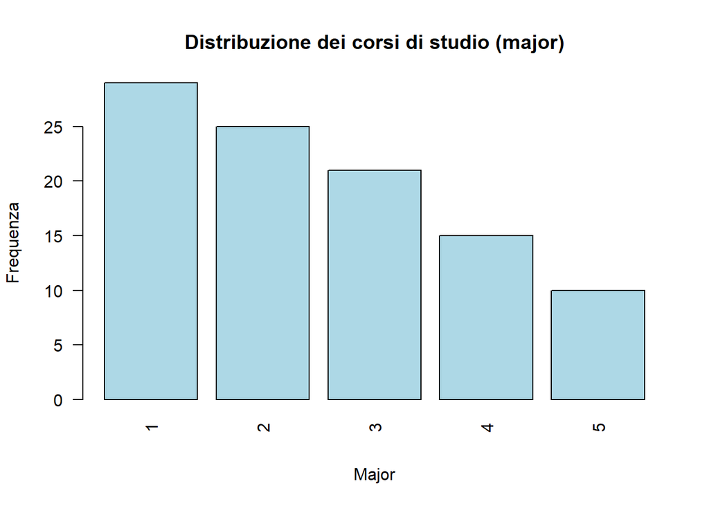

```r
freq_major = table(Sara_dataset$major)

barplot(freq_major,
        main = "Distribuzione dei corsi di studio (major)",
        xlab = "Major",
        ylab = "Frequenza",
        col = "lightblue",
        las = 2)
```

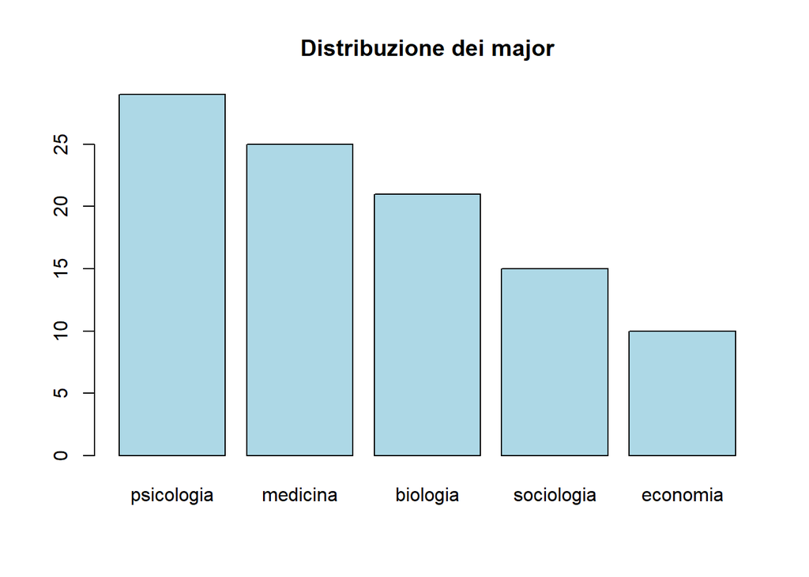

```r
Sara_dataset$major = factor(Sara_dataset$major,
                             labels = c("psicologia", "medicina",
                                        "biologia", "sociologia", "economia"))

freq_major = table(Sara_dataset$major)

barplot(freq_major,
        main = "Distribuzione dei major",
        col = "lightblue")
```

# Terzo capitolo

- Correlazione tra numero corsi di matematica frequentati (prevmath) e punteggio ad un test statistico (statquiz)

```r
cor(Sara_dataset$prevmath, Sara_dataset$statquiz, use = "complete.obs")
```

```
[1] 0.3618062
```

```r
# 3. Test di significatività
test_cor <- cor.test(Sara_dataset$prevmath,
                     Sara_dataset$statquiz,
                     method = "pearson")

test_cor
```

```
    Pearson's product-moment correlation

data:  Sara_dataset$prevmath and Sara_dataset$statquiz
t = 3.842, df = 98, p-value = 0.0002167
alternative hypothesis: true correlation is not equal to 0
95 percent confidence interval:
 0.1780406 0.5211861
sample estimates:
      cor
0.3618062
```

- Interpretazione: correlazione significativa

[figure not shown]

molto bello questo articolo! (Clerici et al., 1996)

secondo Clerici et al. (1996) è una bella giornata

Wilkinson (1999)

# Conclusione

- Prima ho studiato come la fobia influenza il punteggio al quiz di matematica e se c’è una relazione statisticamente significativa tra le due variabili.
- Poi ho indagato quante persone frequentano ogni corso.
- Inifine ho fatto una correlazione tra numero corsi di matematica frequentati (prevmath) e punteggio ad un test statistico è la correlazione è risultata significativa

## References

Clerici, M., Lugo, F., Papa, R., & Penati, G. (1996). Disturbi alimentari e contesto psicosociale. *Bulimia, Anoressia e Obesità in Trattamento Ospedaliero*.

Wilkinson, L. (1999). Statistical methods in psychology journals: Guidelines and explanations. *American Psychologist*, *54*(8), 594.